# 01b_USDA

# UNIT 3 - LOGISTIC REGRESSION

## MODELING THE EXPERT - INTRO TO LOGISTIC REGRESSION

Analytics can create a model based on an expert physician in order to asssess quality of healthcare provided to patients via a technique called **logistic regression**.

D2Hawkeye, a medical data mining company, receives claims data that are generated when an insured patient goes to a medical provider to receive a diagnosis, to undergo a procedure, or to obtain prescription drugs. The medical providers need to get compensated for their work, and claims data provide the means for them to be paid.

An important question to ask is whether we can assess the quality of health care given this claims data. But first, we should ask why is assessing the quality of healthcare is an important objective? This is because if one can identify patients that have recieved a low quality of care, one can interven and attempt to improve for these patients as well as control costs more effectively.

However, defining “quality” is a complex task. There is not a well-defined, algorithmically-understood way of defining “quality”. Currently, assessing quality is done by physicians who are experts in the health space, using their knowledge, expertise, and their intuition.

But, physicians are, of course, humans and are limited by both memory and time, as well as any possible stressors. They typically evaluate quality by examining a patient’s records, which is a time-consuming and inefficient process. Obviously, physicians cannot assess quality for millions of patients, a quantity which D2Hawkeye recieved from patients on a monthly basis and that needed to be assessed.

So the key question is as follows: *Can we develop analytics tools that replicate expert assessment on a large scale*?

The goal here is to learn from expert human judgment by developing a model, interpreting the results of said model, and further adjusting the model to improve predictability. The objective is to make accurate predictions and evaluations on a large-scale basis to be able to process and assess health care quality for millions of people.

### Building the dataset

Medical claims are generated when a patient visits a doctor and include descriptors like diagnosis code, procedures codes, provider information, as well as cost information. Pharmacy claims involve prescription drugs, the quantity of these drugs, the prescribing doctor, as well as medication costs. These two types of data make up our claims data, which are electronically available, standardized, and use well-established codes. However, since humans generate these data, they are not 100% accurate or clear, and we must often deal with under-reporting, since recording claims is a tedious job, and as a result, people under-report them.

In creating the data set, the objective was to assess health care quality, so large health insurance claims database was used and 131 diabetes patients with ages ranging between 35-55 and medical costs ranging from $10k-$20k were randomly selected from the time period between September 1, 2003 to August 31, 2005. An expert physician reviewed these sample claims and wrote descriptive notes, like “ongoing use of narcotics”; “only on Avandia, not good 1st choice drug”; “had regular visits, mammogram, and immunizations”; “was given home testing supplies”, etc.

After this review, this expert physician rated quality of care on a 2-point scale, `poor` or `good`. Examples included, “I’d say care was poorly treated diabetes”, “Not an eye exam, but overall I’d say high quality”. Based on these comments, we extracted an outcome and predictors. The outcome was the “quality of care” and predictors involved the diabetes treatment variables, patient demographics, health care utilization, providers, claims, and prescriptions. The outcome was modeled as a numeric binary variable with a value of `1` for low-quality care and a value of `0` for high-quality care.

## Logistic Regression

**Logistic Regression** predicts the probability of an outcome being `TRUE`. In this example, the logistic regression model will predict the probability a patient is receiving poor care,`P(y = 1)`, which is the complement of the probability that a patient is receiving good care, , i.e. `1 - P(y = 1)`. Just like in linear regression, we have a set of predictors `x_k`, and to predict `P(y = 1)`, we use the **logistic response function**, or **sigmoid function**: `P(y = 1) = 1 / (1 + e^-(B0 + B1x1 + B2x2 + ... + Bkxk))`

This seems like a complicated, nonlinear transformation of the linear regression equation (which can be seen in exponent in the denominator), and this formula is used to produce a number between 0 and 1. The sigmoid function *always* takes values between 0 and 1, which makes sense, since it is estimating a probability. A positive coefficient value for a predictor increases the value of the linear regression exponent in the sigmoid function, which in turn increases `P(y = 1)`, while a negative coefficient value for a variable decreases the linear regression piece, which in turn decreases P(y = 1). The coefficient values (betas) of this model are selected to ensure a high probability of P(y = 1) for the actual “poor care”" cases and to ensure a low probability of P(y = 1) for the actual “good care” cases.

Another useful way to think about the sigmoid function is in terms of **odds**, like in gambling. We can define the odds as `Odds = P(y = 1)/P(y = 0)`. From this, we can see that the odds are greater than 1 if P(y = 1) is higher, are less than 1 if P(y = 0) is higher, and are equal to 1 if both outcomes are equally likely. If you substitute the sigmoid function in for the probability division in this Odds equation, you’d see that Odds are equal to “e” raised to the power of the linear regression equation: `Odds = e^(B0 + B1x1 + B2x2 + ... + Bkxk)`

By taking the **log** of both sides, the **log(Odds)**, or **Logit**, looks exactly like the linear regression equation: `log(Odds) = (B0 + B1x1 + B2x2 + ... + Bkxk)` This helps us understand how coefficient values (betas) affect our prediction of the probability.

- A positive beta increases Logit, which in turn increases the Odds that P(y = 1)
- A negative beta value decreases Logit, which in turn decreases the Odds that P(y = 1)

Suppose the coefficients of a logistic regression model with 2 predictors are as follows: B0 = -1.5, B1 = 3, B2 = -0.5. Suppose we have an observation with the following values for the predictors: x1 = 1, x2 = 5.

- logit = log(odds) = (B0 + B1x1 + B2x2 + … + Bkxk)
- logit = -1.5 + 3*1 + -0.5*5 = -1 = decreases Odds P(y = 1)

The value of the Odds for this observation are `e^logit = e^-1 = 1/e = 0.3678794`, and the value of P(y = 1) for this observation is `1 / (1 + e^-(logit))` which is `1 / 1 + e^-(-1)` = `1 / (1 + e)` = `0.2689414`

# Code

```r
quality <- read.csv("../data/quality.csv")
str(quality)
```

```
## 'data.frame':    131 obs. of  14 variables:
##  $ MemberID            : int  1 2 3 4 5 6 7 8 9 10 ...
##  $ InpatientDays       : int  0 1 0 0 8 2 16 2 2 4 ...
##  $ ERVisits            : int  0 1 0 1 2 0 1 0 1 2 ...
##  $ OfficeVisits        : int  18 6 5 19 19 9 8 8 4 0 ...
##  $ Narcotics           : int  1 1 3 0 3 2 1 0 3 2 ...
##  $ DaysSinceLastERVisit: num  731 411 731 158 449 ...
##  $ Pain                : int  10 0 10 34 10 6 4 5 5 2 ...
##  $ TotalVisits         : int  18 8 5 20 29 11 25 10 7 6 ...
##  $ ProviderCount       : int  21 27 16 14 24 40 19 11 28 21 ...
##  $ MedicalClaims       : int  93 19 27 59 51 53 40 28 20 17 ...
##  $ ClaimLines          : int  222 115 148 242 204 156 261 87 98 66 ...
##  $ StartedOnCombination: logi  FALSE FALSE FALSE FALSE FALSE FALSE ...
##  $ AcuteDrugGapSmall   : int  0 1 5 0 0 4 0 0 0 0 ...
##  $ PoorCare            : int  0 0 0 0 0 1 0 0 1 0 ...
```

```r
summary(quality)
```

```
##     MemberID     InpatientDays       ERVisits       OfficeVisits
##  Min.   :  1.0   Min.   : 0.000   Min.   : 0.000   Min.   : 0.00
##  1st Qu.: 33.5   1st Qu.: 0.000   1st Qu.: 0.000   1st Qu.: 7.00
##  Median : 66.0   Median : 0.000   Median : 1.000   Median :12.00
##  Mean   : 66.0   Mean   : 2.718   Mean   : 1.496   Mean   :13.23
##  3rd Qu.: 98.5   3rd Qu.: 3.000   3rd Qu.: 2.000   3rd Qu.:18.50
##  Max.   :131.0   Max.   :30.000   Max.   :11.000   Max.   :46.00
##    Narcotics      DaysSinceLastERVisit      Pain         TotalVisits
##  Min.   : 0.000   Min.   :  6.0        Min.   :  0.00   Min.   : 0.00
##  1st Qu.: 0.000   1st Qu.:207.0        1st Qu.:  1.00   1st Qu.: 8.00
##  Median : 1.000   Median :641.0        Median :  8.00   Median :15.00
##  Mean   : 4.573   Mean   :480.6        Mean   : 15.56   Mean   :17.44
##  3rd Qu.: 3.000   3rd Qu.:731.0        3rd Qu.: 23.00   3rd Qu.:22.50
##  Max.   :59.000   Max.   :731.0        Max.   :104.00   Max.   :69.00
##  ProviderCount   MedicalClaims      ClaimLines    StartedOnCombination
##  Min.   : 5.00   Min.   : 11.00   Min.   : 20.0   Mode :logical
##  1st Qu.:15.00   1st Qu.: 25.50   1st Qu.: 83.5   FALSE:125
##  Median :20.00   Median : 37.00   Median :120.0   TRUE :6
##  Mean   :23.98   Mean   : 43.24   Mean   :142.9
##  3rd Qu.:30.00   3rd Qu.: 49.50   3rd Qu.:185.0
##  Max.   :82.00   Max.   :194.00   Max.   :577.0
##  AcuteDrugGapSmall    PoorCare
##  Min.   : 0.000    Min.   :0.0000
##  1st Qu.: 0.000    1st Qu.:0.0000
##  Median : 1.000    Median :0.0000
##  Mean   : 2.695    Mean   :0.2519
##  3rd Qu.: 3.000    3rd Qu.:0.5000
##  Max.   :71.000    Max.   :1.0000
```

So we have 131 patients and 14 variables, 13 of which are predictors plus the outcome `PoorCare`:

We must turn `PoorCare` into the factor it’s supposed to be:

```r
library(tidyverse)
library(magrittr)
quality %<>%
  mutate(PoorCare = factor(PoorCare))
table(quality$PoorCare)
```

```
##
##  0  1
## 98 33
```

98 patients had good care, while 33 had poor care.

Let’s look at a simple scatterplot for `OfficeVisits` vs. `Narcotics`.

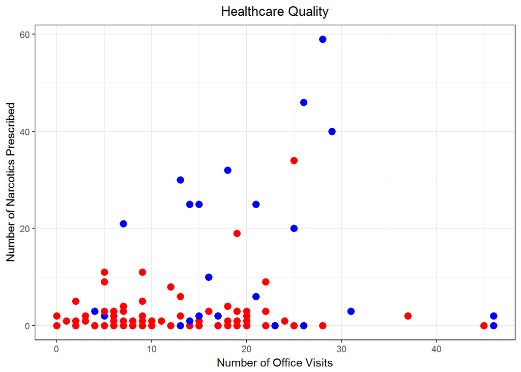

```r
colors <- c("blue","red")

ggplot(quality, aes(OfficeVisits, Narcotics)) +
  geom_point(size = 3, aes(colour = PoorCare)) +
  scale_colour_manual(values = c("red","blue")) +
  theme_bw() +
  ggtitle("Healthcare Quality") +
  theme(legend.position = "none", # remove legend)
        plot.title = element_text(hjust = 0.5)) + # center title
  xlab("Number of Office Visits") +
  ylab("Number of Narcotics Prescribed")
```

It’s hard to see a trend in the data by just visually inspecting it, but it looks like maybe more office visits and more narcotics (to the right and upper portions of the plot) are more likely to have poor care. But a model will help us predict this with more confidence.

Before building any models, one should consider using a simple baseline method. When we computed R2 for a linear regression, we compared our predictions to the baseline of the average value for the outcome for all data points. For this case, we are doing **classification**, and here a standard baseline method would be to just to predict, for all data points, the most frequent outcome from all observations. Since above we saw that good care is more common than poor care (98 vs. 33), we’ll predict “all patients are receiving good care” for our baseline model. If we did this, 98/131 observations would be correct, giving an accuracy of ~75%, which we’ll try to beat with a logistic regression model.

## Split Data

We onlt have one dataset, and we want to randomly split this data into a training and a testing test set that we can use to train the model and then to measure out-of-sample accuracy, respectively.

```r
library(caTools) # for splitting
set.seed(88)
# get 75% of patients in both training and test get good care such that test is representative of training
spl <- sample.split(quality$PoorCare, SplitRatio = 0.75)
train <- subset(quality, spl == T)
test <- subset(quality, spl == F)
```

Let’s build a simple model with just `OfficeVisits` and `Narcotics`.

```r
# build generalized linear model via glm() and "family = binomial" to specify logistic
log_model <- glm(PoorCare ~ OfficeVisits + Narcotics, train, family = "binomial")
summary(log_model)
```

```
##
## Call:
## glm(formula = PoorCare ~ OfficeVisits + Narcotics, family = "binomial",
##     data = train)
##
## Deviance Residuals:
##      Min        1Q    Median        3Q       Max
## -2.06303  -0.63155  -0.50503  -0.09689   2.16686
##
## Coefficients:
##              Estimate Std. Error z value Pr(>|z|)
## (Intercept)  -2.64613    0.52357  -5.054 4.33e-07 ***
## OfficeVisits  0.08212    0.03055   2.688  0.00718 **
## Narcotics     0.07630    0.03205   2.381  0.01728 *
## ---
## Signif. codes:  0 '***' 0.001 '**' 0.01 '*' 0.05 '.' 0.1 ' ' 1
##
## (Dispersion parameter for binomial family taken to be 1)
##
##     Null deviance: 111.888  on 98  degrees of freedom
## Residual deviance:  89.127  on 96  degrees of freedom
## AIC: 95.127
##
## Number of Fisher Scoring iterations: 4
```

We see that `OfficeVisits` is moderately signficiant, `Narcotics` is *barely* signficiant, and both coefficients are positive, so a higher value of these predictors indicates a higher chance of poor care, which is what we expected with higher drug use and more office visits.

Look at the **AIC**, the **Akaike information criterion**. This is a measure of the relative quality of the model. It gives estimate of the information lost when a given model is used to represent the process that generated the data and deals with the trade-off between goodness of fit and simplicity of the model. It’s like the adjusted R2 in linear regression in that it accounts for model complexity. Unfortunately, since it’s relative for the same data, it can only be compared between models on the same data set.It doesn’t provide a test of a model in the sense of testing a null hypothesis as it tells nothing about the *absolute quality* of a model, only the quality relative to other models. Thus, if all models fit poorly, AIC gives no warning. But, this does provide a means for model selection for that data set. **The preferred model has the minimum AIC value, relatively speaking**.

Prior to working on minimizing this, let’s make some predictions using this model on the *training* set.

```r
prediction_train <- predict(log_model, type = "response") # response = predict probability
summary(prediction_train)
```

```
##    Min. 1st Qu.  Median    Mean 3rd Qu.    Max.
## 0.06623 0.11912 0.15967 0.25253 0.26765 0.98456
```

Now let’s see if we are predicting higher probability values for the actual poor care cases, as we hope to do.,

```r
# split predictions into actual good vs. poor cases, get mean of the probabities of each case
tapply(prediction_train, train$PoorCare, mean)
```

```
##         0         1
## 0.1894512 0.4392246
```

From this outpute, we see that for all true poor cases, the average probability is ~44%, and for all true good cases, the average probability is ~18%. This is a good sign, as we’re predicting a higher `P(y = 1)` for the truly poor care cases.

## Accuracy

Once we have a model, we need to assess the accuracy of our predictions. Let’s look at a model that predicts `PoorCare` using `StartedOnCombination` and `ProviderCount`.

```r
log_model2 <- glm(PoorCare ~ StartedOnCombination + ProviderCount, train, family = "binomial")
summary(log_model2)
```

```
##
## Call:
## glm(formula = PoorCare ~ StartedOnCombination + ProviderCount,
##     family = "binomial", data = train)
##
## Deviance Residuals:
##      Min        1Q    Median        3Q       Max
## -1.61826  -0.72782  -0.64555  -0.08407   1.94662
##
## Coefficients:
##                          Estimate Std. Error z value Pr(>|z|)
## (Intercept)              -2.00097    0.55097  -3.632 0.000282 ***
## StartedOnCombinationTRUE  1.95230    1.22342   1.596 0.110541
## ProviderCount             0.03366    0.01983   1.697 0.089706 .
## ---
## Signif. codes:  0 '***' 0.001 '**' 0.01 '*' 0.05 '.' 0.1 ' ' 1
##
## (Dispersion parameter for binomial family taken to be 1)
##
##     Null deviance: 111.89  on 98  degrees of freedom
## Residual deviance: 104.37  on 96  degrees of freedom
## AIC: 110.37
##
## Number of Fisher Scoring iterations: 4
```

`StartedOnCombination` is a binary predictor, which gives `1` if patient is started on a combination of drugs to treat diabetes and gives `0` if they’re not. All else being equal, this model implies that starting a patient on a combination of drugs is indicative of poor care, due to the positive coefficient value.

# Predictions

The outcome of a logistic regression model are a bunch of probability values, but often, we want to make an actual prediction for the outcome. We can convert probabilities to actual predictions using a **threshold** value, **t**. If the probability of `PoorCare` is greater than or equal to the threshold value [ P(y = 1) >= t ], we’ll predict poor care. But, if the probability of `PoorCare` is less than the threshold value [ P(y = 1) < t ], we’ll predict good.

A value for t is often selected based on which types errors are “better” to make. We know that model that predicts perfectly with no errors is the optimal scenario, but this is basically impossible in practice. The two types of errors are **type I errors**, or **false positives** (predicting poor care when the true care was good), and **type II errors**, or **false negatives** (predicting good care when true care was poor).

A larger value for t means that we’d rarely predict poor care, because since P(y = 1) would have to be very large in order to be greater than t. This also means that we’d have more false negatives, but also would correctly detect the patients with the highest probability of receiving poor care and make us able to prioritize these patients for intervention. But, if the value for t is too small, we’d rarely predict good care, because since P(y = 1) would *not* have to be large in order to be greater than t. This also means that we’d have more false positives, but we’d would a higher percentage of patients who have higher chances of receiving poor care.

Some decision-makers often have a preference for one 1 type of error over the other, which influences the choice of the value for t. If there’s no preference between the errors, the threshold to start with is `t = 0.5`, since this just predicts most likely outcome.

Let’s look at a confusion matrix to compare actual outcomes to predicted outcomes with an initial value of 0.5 for t.

```r
(cm <- table(train$PoorCare, prediction_train > 0.5))
```

```
##
##     FALSE TRUE
##   0    70    4
##   1    15   10
```

On the left, we have the values for the *actual* outcome values, with the *predicted* outcome values on the top. In the top left cell of the 2x2 matrix, we have True Negatives, and in the bottom right we have True Positives, while in the top right we have thhe False Positives, with the False Negatives appearing in the bottom left. From these, we can compute the **sensitivity** and **specificity** measures to help us determine what types of errors we are making.

**Sensitivity**, or the **True Positive Rate (TPR)**, measures the percentage of true poor care cases that we classified correctly, and is equal to the true positives divided by the sum of the true positives and the false negatives.

**Specificity/Recall**, or the **True Negative Rate (TNR)**, measures the percentage of actual good care cases that we classified correctly, and is equal to the true negatives divided by sum of the true negatives and the false positives.

A model with a higher t value gives more False Negatives, which means we’d have a lower Sensitivity (less true poor care cases identified correctly) and a higher Specificity (more true good care cases identified correctly). Meanwhile, a model with a lower t value gives more False Positives, which means we’d have a lower Specificity (less true good care cases identified correctly) and a higher Sensitivity (true poor care cases identified correctly).

For the above confusion matrix, we have 70 True Negatives, 10 True Positives, 4 False Positives, and 15 False Negatives, and from this we have

```r
sensitivity <- cm[4] / (cm[4] + cm[2]) # true positive rate = TP / (TP + FN)
specificity <- cm[1] / (cm[1] + cm[3]) # recall = true negative rate = TN / (TN + FP)
precision <- cm[1] / (cm[1] + cm[2]) # TP / predicted Pos
accuracy <- (cm[4]+cm[1]) / sum(cm) # TP + TN / n

cat("Threshold = 0.5")
```

```
## Threshold = 0.5
```

```r
cat("\nSensitivity (TP rate): ",sensitivity)
```

```
##
## Sensitivity (TP rate):  0.4
```

```r
cat("\nSpecificity (TN rate or Recall): ",specificity)
```

```
##
## Specificity (TN rate or Recall):  0.9459459
```

```r
#cat("\nPrecision (Positive Predictive Value): ",precision)
cat("\nAccuracy: ",accuracy)
```

```
##
## Accuracy:  0.8080808
```

Let’s look at what happens with a threshold value of 70%.

```r
(cm <- table(train$PoorCare, prediction_train > 0.7))
```

```
##
##     FALSE TRUE
##   0    73    1
##   1    17    8
```

```r
sensitivity <- cm[4] / (cm[4] + cm[2]) # true positive rate = TP / (TP + FN)
specificity <- cm[1] / (cm[1] + cm[3]) # recall = true negative rate = TN / (TN + FP)
precision <- cm[1] / (cm[1] + cm[2]) # TP / predicted Pos
accuracy <- (cm[4]+cm[1]) / sum(cm) # TP + TN / n

cat("Threshold = 0.7")
```

```
## Threshold = 0.7
```

```r
cat("\nSensitivity (TP rate): ",sensitivity)
```

```
##
## Sensitivity (TP rate):  0.32
```

```r
cat("\nSpecificity (TN rate or Recall): ",specificity)
```

```
##
## Specificity (TN rate or Recall):  0.9864865
```

```r
#cat("\nPrecision (Positive Predictive Value): ",precision)
cat("\nAccuracy: ",accuracy)
```

```
##
## Accuracy:  0.8181818
```

So, by increasing t, our Specificity/Recall increased while Sensitivity decreased, meaning we have less True Positives and/or more True Negatives. Our accuracy has also increased in this scenario.

Now let’s drop the threshold to 20%

```r
(cm <- table(train$PoorCare, prediction_train > 0.2))
```

```
##
##     FALSE TRUE
##   0    54   20
##   1     9   16
```

For the above confusion matrix, we have 54 True Negatives, 16 True Positives, 20 False Positives, and 9 False Negatives, and from this we have

```r
sensitivity <- cm[4] / (cm[4] + cm[2]) # true positive rate = TP / (TP + FN)
specificity <- cm[1] / (cm[1] + cm[3]) # recall = true negative rate = TN / (TN + FP)
precision <- cm[1] / (cm[1] + cm[2]) # TP / predicted Pos
accuracy <- (cm[4]+cm[1]) / sum(cm) # TP + TN / n

cat("Threshold = 0.2")
```

```
## Threshold = 0.2
```

```r
cat("\nSensitivity (TP rate): ",sensitivity)
```

```
##
## Sensitivity (TP rate):  0.64
```

```r
cat("\nSpecificity (TN rate or Recall): ",specificity)
```

```
##
## Specificity (TN rate or Recall):  0.7297297
```

```r
#cat("\nPrecision (Positive Predictive Value): ",precision)
cat("\nAccuracy: ",accuracy)
```

```
##
## Accuracy:  0.7070707
```

### Decisions

Which threshold should we pick? Picking a good threshold value is often challenging. One thing that can help us decide which threshold value to use is a **Receiver Operator Characteristic (ROC) curve**. The Sensitivity/TP rate of the model is shown on y-axis and the FP Rate (i.e. 1 - specificity/TN Rate) is on the x-axis. A line is graphed on the plot shows how these 2 outcome measures would vary from using different threshold values. An ROC curve always starts at (0, 0), which corresponds to a value of t = 1. This is because if you have t = 1, you will not catch *any* true (poor) cases and will end up with a sensitivity of 0. But, in this case, you will also *correctly* label all of the *false* (good) cases and end up with a FP rate = 0 (or TN rate = 1). The ROC curve then always ends at (1,1) which corresponds to a t value = 0. If you have a value of t = 0, you catch all true (poor) cases to end up with a sensitivity = 1 but incorrectly label all false (good) cases too, meaning you get a FP rate = 1 (TN rate = 0).

So, as t decreases, you move from (0,0) to (1,1) on the ROC plot. For example, at (0, 0.4), you’re correctly labeling about 40% of true (poor) cases with a very small FP rate (a “medium” value on the y-axis and a “low” value on the x-axis). On the other hand, at (0.6, 0.9), you’re correctly labeling about 90% of true (poor) cases, but with a FP rate of 60%. In the middle, around (0.3, 0.8), you’re correctly labeling about 80% of true (poor) cases, with a 30% FP rate.

The ROC curve captures *all* thresholds simultaneously. The higher the t value/the closer to (0, 0) on the plot, the higher the specificity and the lower the sensitivity. Then, the lower the t value/the closer to (1,1) on the plot, the higher the sensitivity and lower the specificity.

One should select the best threshold contigent on the trade-off one is willing to make. If you’re more concerned with having a high specificity/a low FP rate, pick the threshold that maximizes the TP rate while keeping FP rate really low. This comes with a risk of failing to detect some positive cases. On the other hand, if you’re more concerned with having a high sensitivity/a high TP rate, pick a threshold that minimizes FP rate but has a very high TP rate, and this hasa risk of raising false alarms.

You can label the threshold values in R by color-coding the curve w/ a legend is shown on the right. We can also add specific threshold labels to points on the curve to help see which threshold value you want to use.

# A threshold around (0.1, 0.5) on this ROC curve looks like a good choice in this case = high spec/low fp rate

# A threshold around (0.3, 0.8) looks like a good choice in this case = high sens/high tp

```r
#install.packages("ROCR")
library(ROCR)
```

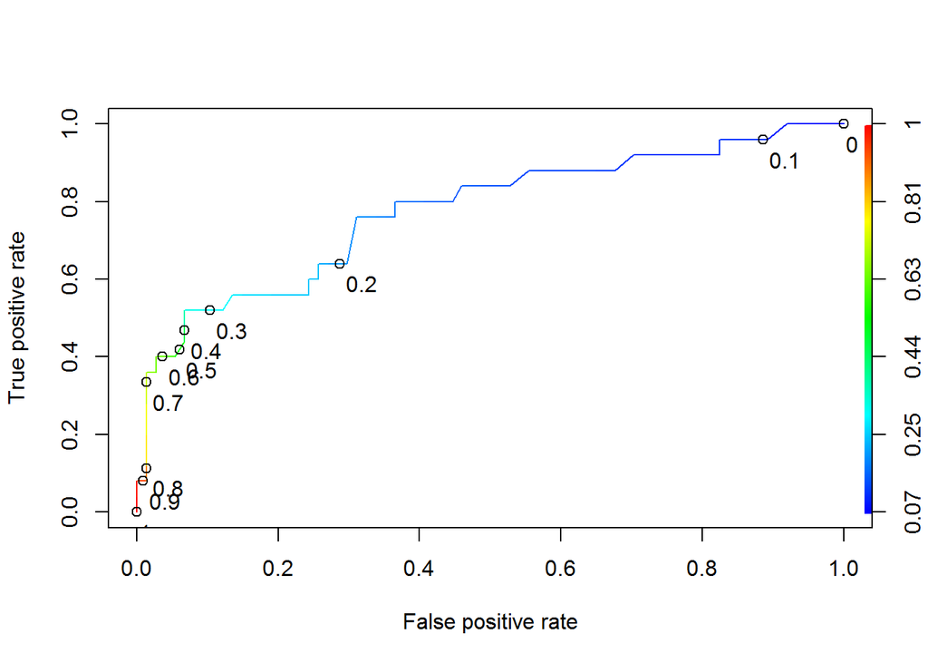

```r
# prediction(model predictions, labels[, ordering])
ROCRpred_train <- prediction(prediction_train, train$PoorCare)

# performance(prediction object output, x-axis values, y-axis values)
ROCRperf <- performance(ROCRpred_train, x.measure = "fpr", measure = "tpr")

# Plot t-values ffrom 0 to 1 in increments of 0.1
plot(ROCRperf, colorize = T, print.cutoffs.at = seq(0,1,.1), text.adj = c(-.2,1.7))
```

With this curve, we can determine which threshold value we’d want to use depending on our preferences of a trade-off as a decision-maker. If we want to identify the most critical patients with a high confidence, we want a maximized TP rate/sensitivity while keeping the FP rate minmized. A good value of t for this loooks to be 0.7. Meanwhile, if we want to identify about half of the patients receiving poor care correctly while raising as few false alarms as possible (misidentifying as little cases as possible), a good value of t for this would be around 0.3 (TP rate is around 50%, with the smallest FP rate for this TP rate)

### Interpreting the Model

One of the most important things to look for when interpreting a model is that there might be **multicollinearity** in the model, wherein the various predictors are highly correlated which may “confuse” the coefficients/betas in the model. Tests to address this possible scenario involve checking and comparing the correlations between the predictors. If they’re excessively high, this means there might be multicollinearity and you’d potentially have to revisit the model as well as make sure the coefficients and their signs make sense? If the sign agrees with intuition, then multicollinearity probably isn’t a problem, but if intuition suggests a different sign, this might be a sign of multicollinearity.

To interpret the model results and to try and understand whether we have a good model or not, we can look at the **Area Under the Curve (AUC)**, which shows an absolute measure of the quality of prediction, noting that a “perfect score” is 1 (or 100%), which is more to the right and upper portions of the plot, and a score of .5 (50% rate of success) is equivalent to purely guessing the classification. So, the AUC gives an absolute measure of quality, and is also less affected by various benchmarks while illustrating how accurate the model is on a more “absolute” sense.

The area on the right of an AUC curve shows indicates areas closer to 1, a perfect prediction.

Other outcome measures that are important for us to discuss is the confusion matrix for out-of-sample cases. For quality of care, just like in linear regression, we want to make predictions on a test set to compute out-of-sample metrics. Remember, sensitivity is basically how much we predict `TRUE` for a case and it is *indeed* `TRUE` (TP rate), while specificity is basically how much we predict `FALSE` cases that turn out to *indeed* be `FALSE` (TN rate).

We’ve develop a logistic regression model using our data, but we’d now would like to make predictions on out-of-sample data. In our `test` set, we have 32 cases and we can make statements about the quality of a prediction out-of-sample with:

```r
prediction_test <- predict(log_model, type = "response", newdata = test)
summary(prediction_test)
```

```
##    Min. 1st Qu.  Median    Mean 3rd Qu.    Max.
## 0.07631 0.12931 0.19699 0.27549 0.35731 0.95253
```

```r
# ID 1/2 of patients receiving poor care correctly while raising as few false alarms as possible
(cm <- table(test$PoorCare, prediction_test > 0.3) )
```

```
##
##     FALSE TRUE
##   0    19    5
##   1     2    6
```

```r
# check ROC curve above to see why .3 for t value

table(test$PoorCare)
```

```
##
##  0  1
## 24  8
```

```r
actualFalse <- cm[1] + cm[3]
actualTrue <- cm[2] + cm[4]

predictedFalse <- cm[1] + cm[2]
predictedTrue <- cm[3] + cm[4]

cat("\nPredicted False Cases: ",predictedFalse)
```

```
##
## Predicted False Cases:  21
```

```r
cat("\nPredicted True Cases: ",predictedTrue)
```

```
##
## Predicted True Cases:  11
```

```r
cat("\nActual False Cases: ",actualFalse)
```

```
##
## Actual False Cases:  24
```

```r
cat("\nActual True Cases: ",actualTrue)
```

```
##
## Actual True Cases:  8
```

```r
sensitivity <- cm[4] / (cm[4] + cm[2]) # true positive rate = TP / (TP + FN)
specificity <- cm[1] / (cm[1] + cm[3]) # recall = true negative rate = TN / (TN + FP)
precision <- cm[1] / (cm[1] + cm[2]) # TP / predicted Pos
accuracy <- (cm[4]+cm[1]) / sum(cm) # TP + TN / n

cat("\nSensitivity (TP rate): ",sensitivity)
```

```
##
## Sensitivity (TP rate):  0.75
```

```r
cat("\nSpecificity (TN rate or Recall): ",specificity)
```

```
##
## Specificity (TN rate or Recall):  0.7916667
```

```r
#cat("\nPrecision (Positive Predictive Value): ",precision)
cat("\nAccuracy: ",accuracy)
```

```
##
## Accuracy:  0.78125
```

Now look at the AUC for our original model with `OfficeVisits` and `Narcotics` on the test set.

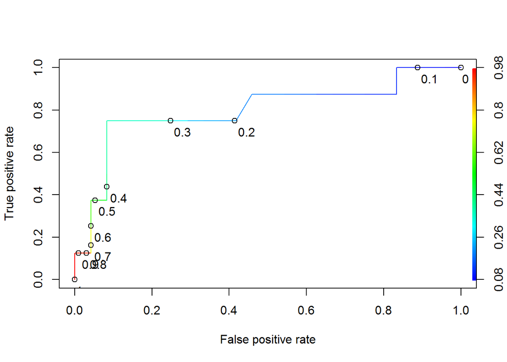

```r
# prediction(model predictions, labels[, ordering])
ROCRpred_test <- prediction(prediction_test, labels = test$PoorCare)

# performance(prediction object output, x-axis values, y-axis values)
ROCRperf_test <- performance(ROCRpred_test, x.measure = "fpr", measure = "tpr")

# Plot t-values ffrom 0 to 1 in increments of 0.1
plot(ROCRperf_test, colorize = T, print.cutoffs.at = seq(0,1,.1), text.adj = c(-.2,1.7))
```

```r
# compute test set AUC with predictions on test set
test_auc = as.numeric(performance(ROCRpred_test, "auc")@y.values)
cat("Test Set AUC: ", test_auc)
```

```
## Test Set AUC:  0.7994792
```

So, this test set AUC of .799 means given a random patient from the dataset who actually received *poor* care, and a random patient from the dataset who actually received *good* care, our model will classify which is which correctly about 80% of the time.

### Conclusion

These logistic regression models provide the **probabilities** of somebody receiving poor quality care, and these probabilities can be used to prioritize patients for intervention, a particularly useful outcome from the study. While the out-of-sample accuracy is reasonably high, 78%, it can be, of course, further improved. In that respect, EMR data + not *just* claims data could be used to enhance the predictive capability of such models.

A model like the one we just built can be used to analyze millions of records, whereas a human can only accurately analyze rather small amounts of information. Clearly, such a model allows significantly larger scalability, but it’s important to note that a model does *not* replace expert judgement. However, models *do* provide a way to translate expert judgement into a reproducible, testable prediction methodology that has significantly higher scalability, and, of course, experts can continuously improve and refine the models. Finally, and quite importantly, models can integrate assessments of *multiple* experts into one final, unbiased, and unemotional prediction. Such methods of combining assessments and combining models is a tool we can use as a way of enhancing and improving quantitative models.